# Notes 4 - Exploratory Data Analysis

### Exploring change at one monitor

```r
site1999 <- unique(subset(pm_1999, State.Code == 36, c(County.Code, Site.ID)))
site1999 <- paste(site1999[,1], site1999[,2], sep=".")
site2013 <- unique(subset(pm_2013, State.Code == 36, c(County.Code, Site.ID)))
site2013 <- paste(site2013[,1], site2013[,2], sep=".")
both <- intersect(site1999, site2013)
both
```

```
##  [1] "1.5"     "1.12"    "5.110"   "13.11"   "29.2"    "29.5"    "31.3"
##  [8] "63.2008" "67.1015" "85.55"   "101.3"
```

```r
# 11 sites in common
# Add the county.site list to the data frames
pm_1999$county.site <- with(pm_1999, paste(County.Code, Site.ID, sep = "."))
pm_2013$county.site <- with(pm_2013, paste(County.Code, Site.ID, sep = "."))
# Get the data from the sites in common, in NY
cnt1999 <- subset(pm_1999, State.Code == 36 & county.site %in% both)
cnt2013 <- subset(pm_2013, State.Code == 36 & county.site %in% both)
```

### Look for a site with a good number of samples

```r
sapply(split(cnt1999, cnt1999$county.site), nrow)
```

```
##    1.12     1.5   101.3   13.11    29.2    29.5    31.3   5.110 63.2008
##      61     122     152      61      61      61     183     144     122
## 67.1015   85.55
##     122       7
```

```r
sapply(split(cnt2013, cnt2013$county.site), nrow)
```

```
##    1.12     1.5   101.3   13.11    29.2    29.5    31.3   5.110 63.2008
##     122     244     122      33      89     119      61     122      31
## 67.1015   85.55
##     122     122
```

```r
# 1.5[122, 244]
# 101.3[152, 122]
# 5.110[144, 122]
# 67.1015[122, 122]
pm1999sub <- subset(pm_1999, State.Code == 36 & County.Code == 67 & Site.ID == 1015)
pm2013sub <- subset(pm_2013, State.Code == 36 & County.Code == 67 & Site.ID == 1015)
```

### Look at change in readings over time in two years

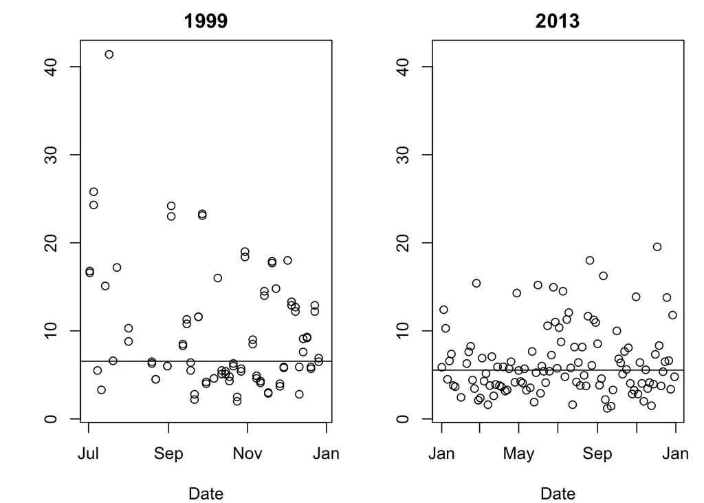

```r
pm1999sub$Date <- as.Date(as.character(pm1999sub$Date), "%Y%m%d")
pm2013sub$Date <- as.Date(as.character(pm2013sub$Date), "%Y%m%d")
par(mfrow = c(1, 2), mar=c(4, 4, 2, 1))
rng <- range(pm1999sub$Sample.Value, pm2013sub$Sample.Value, na.rm=T)
with(pm1999sub, plot(Sample.Value ~ Date, main="1999", ylab="", ylim=rng))
abline(h = median(pm1999sub$Sample.Value, na.rm=T))
with(pm2013sub, plot(Sample.Value ~ Date, main="2013", ylab="", ylim=rng))
abline(h = median(pm2013sub$Sample.Value, na.rm=T))
```

This plot has a couple attempts.

1. two plots in two windows, hard to compare
2. lets add a median line
3. the ylim is different, so hard to compare

The medians are fairly close, but the extremes are less frequent and less extreme in 2013.

### Look at data across states

```r
mean1999 <- with(pm_1999, tapply(Sample.Value, State.Code, mean, na.rm=T))
str(mean1999)
```

```
##  num [1:53(1d)] 19.96 6.67 10.8 15.68 17.66 ...
##  - attr(*, "dimnames")=List of 1
##   ..$ : chr [1:53] "1" "2" "4" "5" ...
```

```r
summary(mean1999)
```

```
##    Min. 1st Qu.  Median    Mean 3rd Qu.    Max.
##   4.862   9.519  12.310  12.410  15.640  19.960
```

```r
mean2013 <- with(pm_2013, tapply(Sample.Value, State.Code, mean, na.rm=T))
str(mean2013)
```

```
##  num [1:52(1d)] 11.21 4.78 8.15 9.87 12.07 ...
##  - attr(*, "dimnames")=List of 1
##   ..$ : chr [1:52] "1" "2" "4" "5" ...
```

```r
summary(mean2013)
```

```
##    Min. 1st Qu.  Median    Mean 3rd Qu.    Max.
##   3.845   7.603   8.966   8.857  10.360  13.480
```

All the measures are lower in 2013 than they were in 1999.

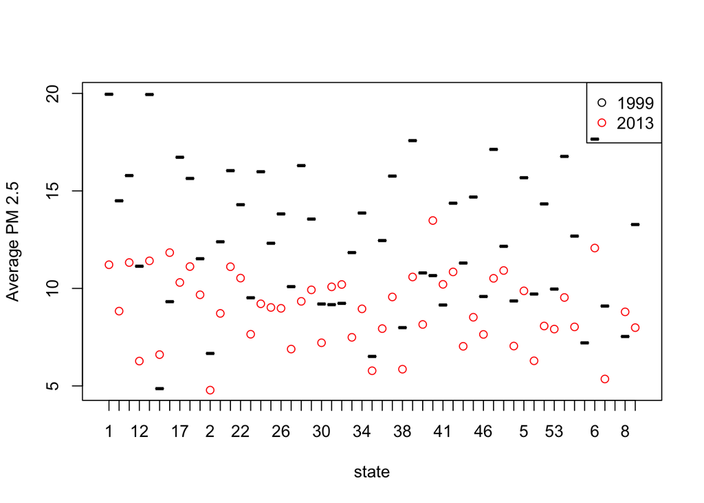

```r
d1999 <- data.frame(state=names(mean1999), mean=mean1999)
d2013 <- data.frame(state=names(mean2013), mean=mean2013)
mrg <- merge(d1999, d2013, by = "state")
names(mrg) <- c("state", "y1999", "y2013")
par(mfrow=c(1,1))
with(mrg, plot(y1999 ~ state, pch=1, ylab="Average PM 2.5"))
with(mrg, points(y2013 ~ state, col="red"))
legend("topright", c("1999", "2013"), pch=c(1, 1), col=c("black", "red"))
```

His plot is different

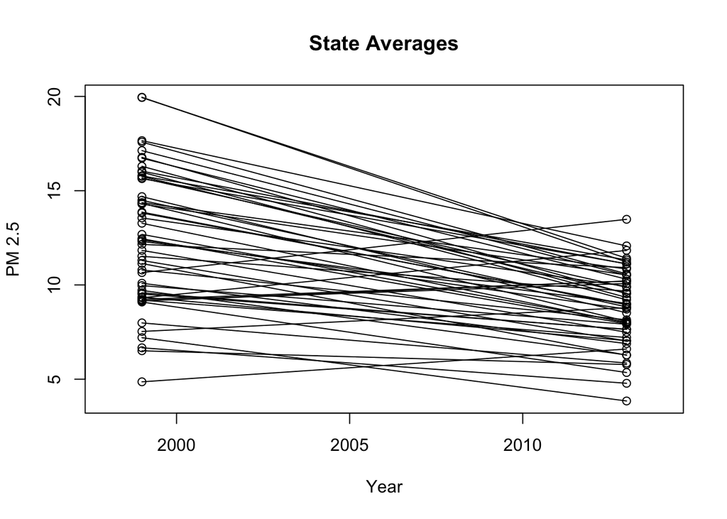

```r
rng=range(mrg[,2], mrg[,3])
with(mrg, plot(rep(1999, 52), mrg[,2], xlim=c(1998, 2014), ylim=rng, main="State Averages", ylab="PM 2.5", xlab="Year"))
with(mrg, points(rep(2013, 52), mrg[, 3]))
segments(rep(1999, 52), mrg[,2], rep(2013, 52), mrg[, 3])
```

Almost all of the states have moved down. A few have moved up.

```r
# Here are the codes for the states that are worse
mrg$state[mrg[,3] > mrg[,2]]
```

```
## [1] 15 16 31 32 40 41 8
## 53 Levels: 1 10 11 12 13 15 16 17 18 19 2 20 21 22 23 24 25 26 27 ... 9
```

```r
# Somewhere there is a name to go with the codes...
```